# Lab 03 - Parte 2

Caio Oliveira

June 26, 2017

# Tema: Agrupamento de mais dados em mais dimensões

## Dados: UFCG - Sumarizados por UA e completos

….

# 1 - TRATAMENTO E DIVISÃO DOS DADOS

Para este laboratório os dados que foram escolhidos são da UFCG e pertencem ao primeiro caso o qual o professor citou na explicação deste relatório. Esses dados podem ser encontrados [aqui](https://github.com/nazareno/tamanhos-da-ufcg).

Em relação ao tratamnto e a divisão dos dados aqui foi feita em duas partes principais. A primeira usa os dados completos da UFCG e foi feita uma análise para tentar ajudar na divisão de grupos e clusterização da segunda parte, que é justamente os dados sumarizados das unidades acadêmicas. Já nessa segunda parte é usado k-means para se fazer a clusterização. Além de no final após ter sido atribuido um valor para k, foi calculado o os melhores valores de K através de aritmética simples e testado para o cenário dos dados. Tirando a dúvida assim da melhor quantidade de grupos.

```r
setwd("~/data-analysis-2/ad1/lab3/")
data <- read_csv("ufcg-201704-unidades-academicas-filtradas.csv", col_types = cols(INGRESSO_SERVICOPUBLICO = col_date()))
data <- na.omit(data)

summ.ua <- read.csv("sumario-ua.csv")

professores <- data %>%
  filter(DESCRICAO_CARGO == "PROFESSOR DO MAGISTERIO SUPERIOR")
```

# 2 - DADOS COMPLETOS

Nssa parte do laboratório foi utilizado os dados complestos dos funcionários da UFCG, que podem ser encontrados [aqui](https://github.com/nazareno/tamanhos-da-ufcg/blob/master/ufcg-201704-unidades-academicas-filtradas.csv). A idéia principal dessa sessão é que analisando esses dados, possamos ter uma base e decidir um valor significativo para o K-númedo de clusters no dataset da sessão seguinte.

## Quando começaram a ser professores?

Primeiramente foi feita uma filtragem nos dados utilizados para que ficassem só os professores no dataset. Além disso foi utilizada uma variável específica aqui **INGRESSO_SERVICOPUBLICO** (data de ingresso como funcionário na universidade).

Essa primeira pergunta que pode nos ajudar a decidir a quantidade de grupos a ser usada é bem útil pois podemos ver se existe algum comportamento em comum entre os professores durante algum período de tempo.

Para isso foi utilizado o gráfico de dispersão em uma dimensão. E pudemos concluir que existem pelo menos 3 grupos definidos de entrada de professores na UFCG. Entretanto não é suficiente para atribuir um valor à K.

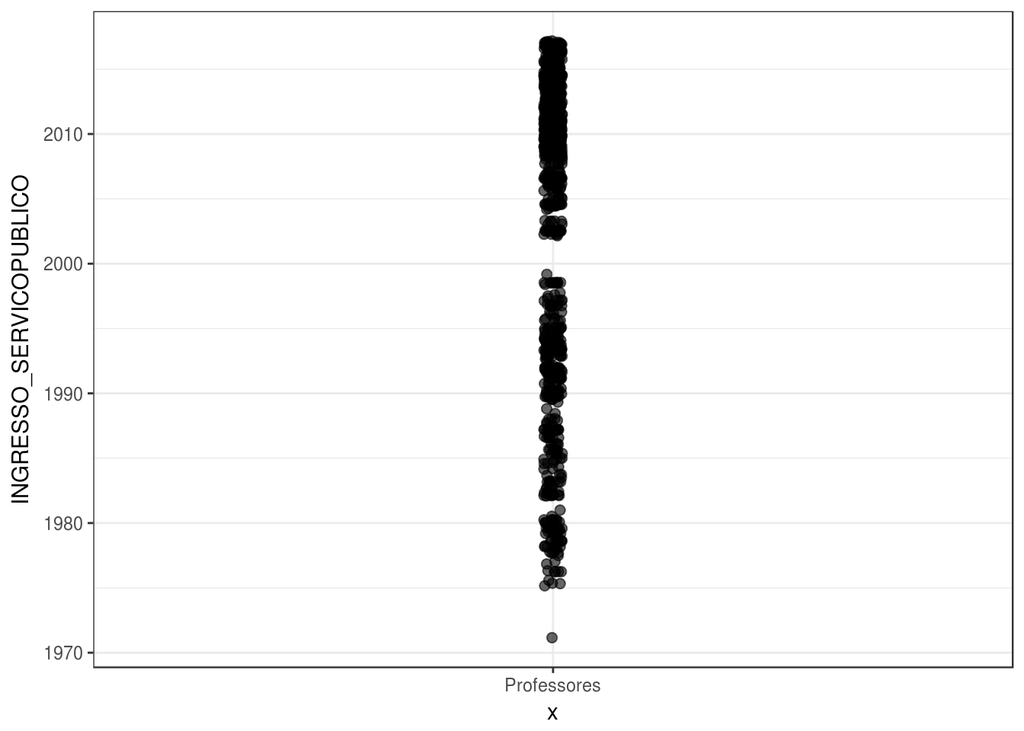

```r
professores %>%
    ggplot(aes(x = "Professores", y = INGRESSO_SERVICOPUBLICO)) + scale_y_date() + theme_bw() +
    geom_jitter(width = .01, height = 0, size = 2, alpha = .6)
```

## Agrupamento em histograma

Uma outra maneira fácil de identificarmos grupos é com o agrupamento no histograma. Então aqui foi utilizada a variável mencionada no gráfico anterior no eixo X, já que no eixo Y fica a contagem de professores que entrou naquela mesma data.

A conclusão dessa visualização é que vemos períodos bem definidos de entrada de professores, sendo eles 4 grupos. Vemos um crescimento consideravel depois de **2002**, qu foi o ano que a UFPB-campus CG se tornou UFCG.

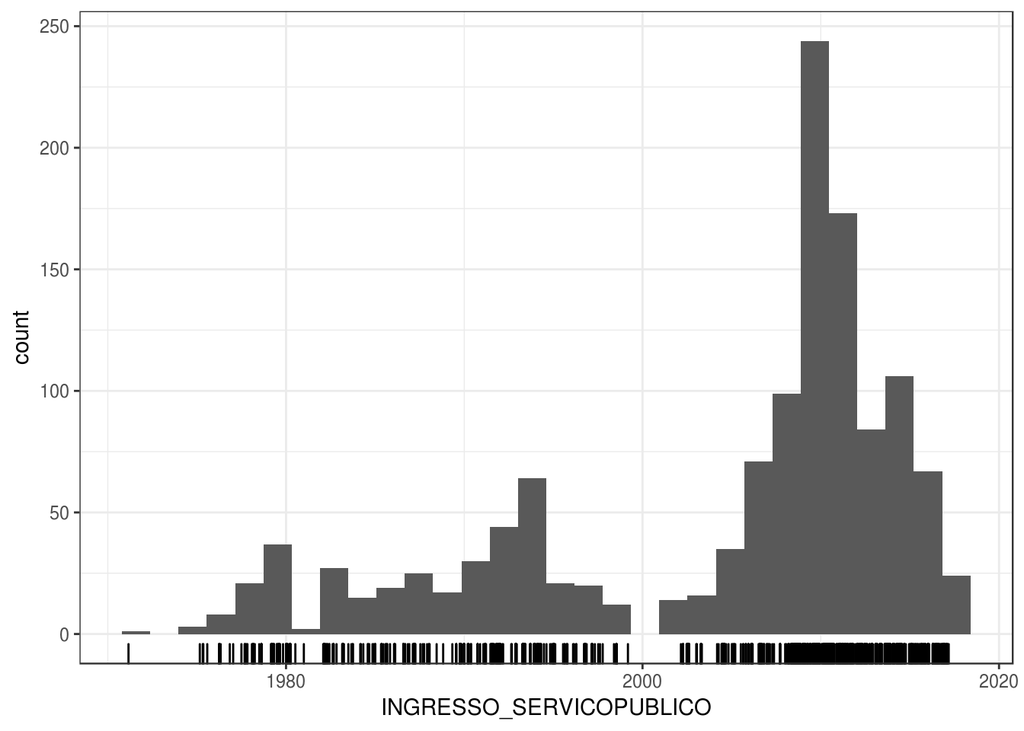

```r
professores %>%
    ggplot(aes(x = INGRESSO_SERVICOPUBLICO))  +
    geom_histogram(bins = 30) +
    geom_rug()
```

## Normalização

Um ultimo recurso de agrupamento poderia ser feito normalizando o histograma. Entretanto o resultado não ajudou tanto a visualização de grupos, inclusive um dos grupos mostrado no gráfico anterior é suprimido por essa normalização.

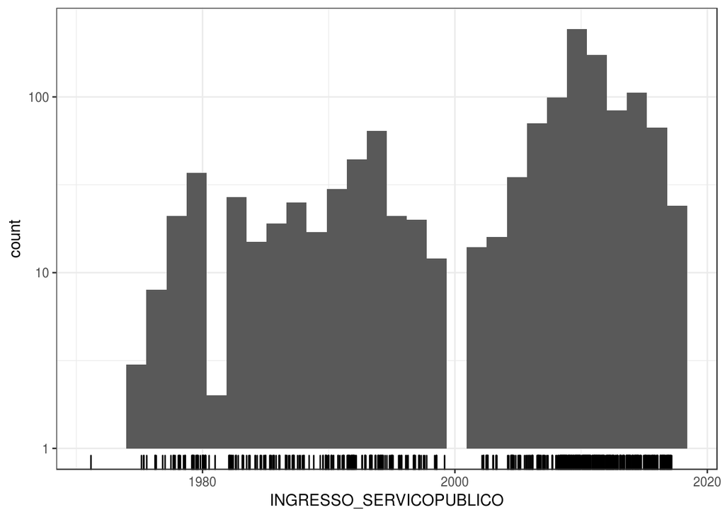

```r
professores %>%
    ggplot(aes(x = INGRESSO_SERVICOPUBLICO))  +
    geom_histogram(bins = 30)  +
    scale_y_log10() +
    geom_rug()
```

## Números por departamento

Como a ideia da próxima sessão é utilizar os dados por unidade acadêmica a melhor coisa a se fazer é primeiro visualizar os dados de uma forma que ajude a conhecer o contexto tratado. E qual melhor forma de conhecer a universidade que conhecendo seus professores?

A ideia aqui é utilizar o histograma novamente mas dessa vez só para contabilizar a quandidade de professores e vermos se isso reflete na universidade e se tem algo a ver com a quantidade de novos professores de 2000 até 2017 .

A conclusão é a força que o curso de medicina teve durante esses anos e o setor separado para saúde proporciona e necessita de um corpo doscente maior. Computação esta em 9° lugar nessa contagem

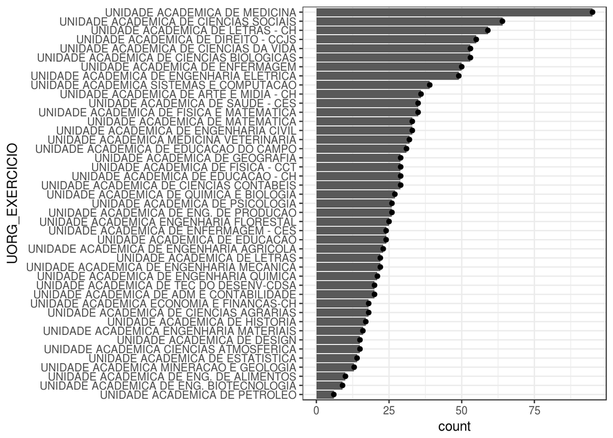

```r
professores <- within(professores,
                   UORG_EXERCICIO <- factor(UORG_EXERCICIO,
                                      levels=names(sort(table(UORG_EXERCICIO),
                                                        decreasing=FALSE))))
professores %>%
  ggplot(aes(x=UORG_EXERCICIO)) + geom_histogram(stat = "count") + geom_point(stat = "count") + coord_flip()
```

# 3 - DADOS POR UNIDADE ACADÊMICA

Aqui foram utilizados os [dados das unidades acadêmicas sumarizados](https://github.com/nazareno/tamanhos-da-ufcg/blob/master/ufcg-201704-sumario-UAs-wide.csv). Os quais foram empregados o propósito de separação em grupos de acordo com o que foi analisado nas sessões anteriores.

Os valores atribuidos para K foram **3** e **4** pelas conclusões que obtive nas visualizações anteriores. Nessa sessão também usaremos **k-means** ao invés de **hclust**, como foi recomendado pelo professor na descrição do laboratório.

## Correlação de fatores

A primeira coisa que podemos analisar é a correlação entre as variáveis do dataset, o quais foram tiradas duas variáveis: **Outro** e **UORG_LOTAÇÃO**. O primeiro por não existir uma definição que seja realmente professor do departamento e o segundo por não ser uma variável numérica, sendo assim inviável a correlação.

Apesar de quase não existir correlação entre a mediana das idades gerais e a quantidade de professores 40 horas, essas duas variáveis serão analisadas mais a frente.

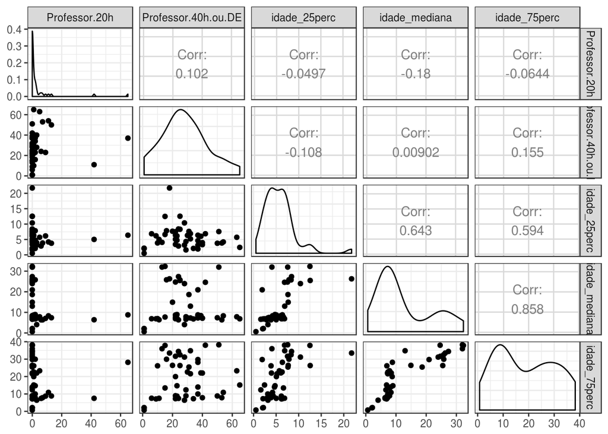

```r
summ.ua %>%
    select(-Outro,-UORG_LOTACAO) %>%
    ggpairs(cardinality_threshold = 50)
```

```r
ua.scaled <- summ.ua %>%
    select(-Outro,-UORG_LOTACAO)
```

## K-means

Vamos utilizar o método k-means que calcula as médias dos pontos para centro dos seus clusters e para o geral dos dados. O **k** simboliza justamente essa quantidade de grupos(clusters) que são reconhecidos pelo método.

### com 3 grupos

O primeiro valor atribuido a **k** foi 3 pois, como o primeiro scatterplot mostrou durante os anos existem 3 grandes concentrações de entradas de professores na UFCG. Então aqui a ideia foi atribuir as variáveis do dataset pesos e atribuir os valores a uma nova variável chamada **.cluster** o qual posicionará os elementos em um outro scatterplot geral com os cluster divididos por cores.

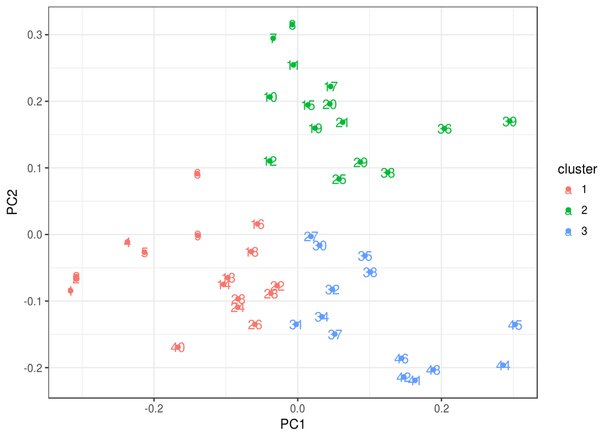

```r
n_clusters <- 3
dw2.scaled <- ua.scaled

km = ua.scaled %>%
    kmeans(centers = n_clusters, nstart = 20)

dw2.scaled.km.long = km %>%
    augment(dw2.scaled) %>%
    gather(key = "variável",
           value = "valor")


autoplot(km, data = dw2.scaled, label = TRUE)
```

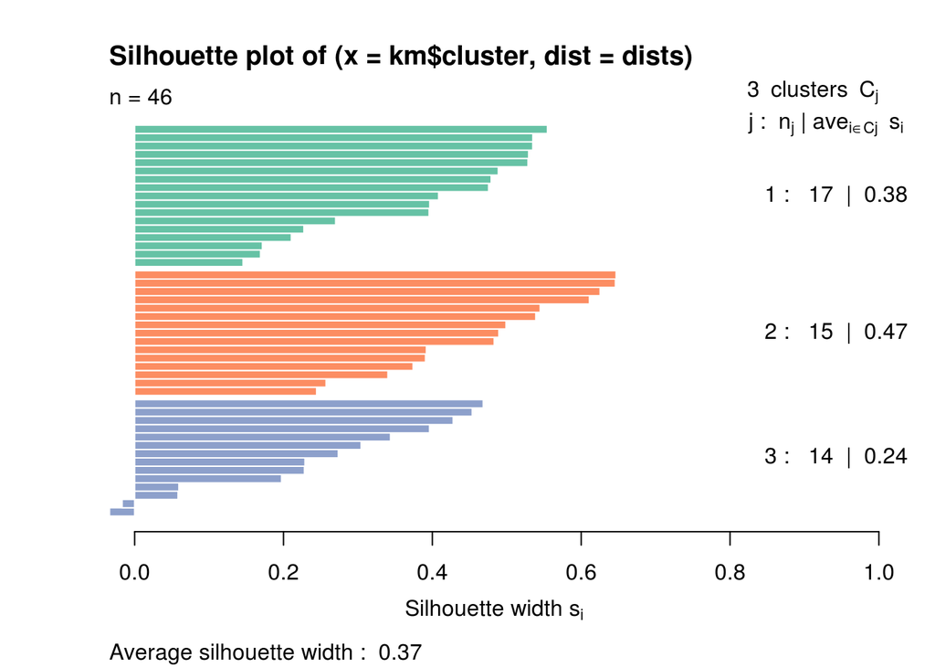

```r
dists = dw2.scaled %>% dist()
plot(silhouette(km$cluster, dists), col = RColorBrewer::brewer.pal(n_clusters, "Set2"))
```

### com 4 grupos

No caso para o valor de **k** igual a 4 a ideia era fazer um scatterplot mas com variáveis bem definidas, sendo elas: **idade_mediana**(tempo de serviço) e **Professor.40h.ou.DE**.

Utilizando o **k-means** foi o melhor resultado de divisão com esse valor pois, podemos ver e definir bem os 4 grupos encontrados.

**Grupo 4 - Na media:** Departamentos com quantidade e anos de experiência na média.

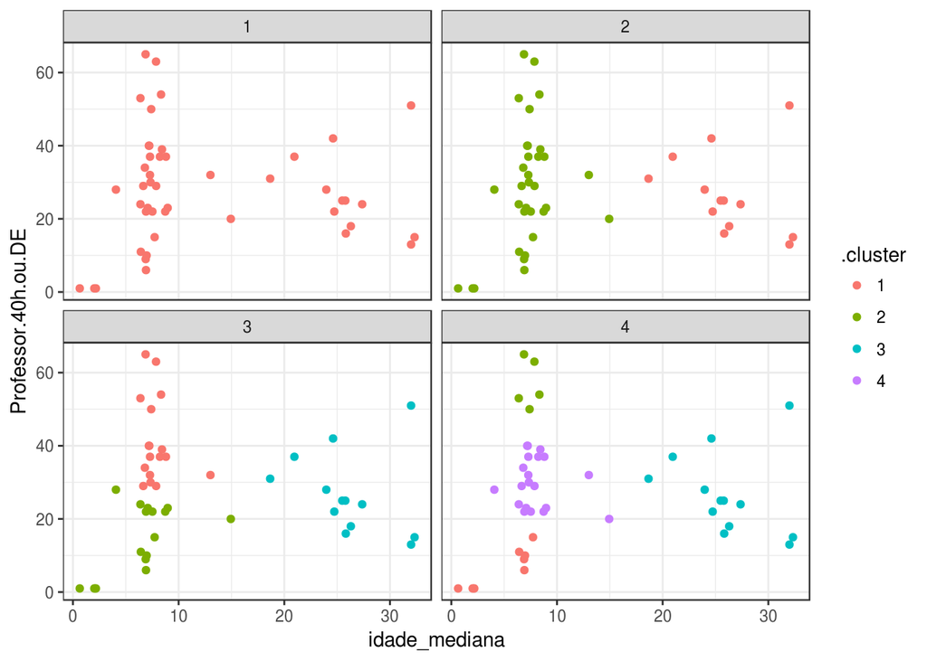

```r
summario_t <- summ.ua  %>%
    select(-Outro) %>%
    mutate_each(funs(as.vector(scale(.))), Professor.40h.ou.DE, idade_mediana)

atribuicoes = tibble(k = 1:4) %>%
    group_by(k) %>%
    do(kmeans(select(summario_t, idade_mediana, Professor.40h.ou.DE),
              centers = .$k,
              nstart = 10) %>% augment(summ.ua)) # alterne entre filmes e filmes_t no augment

atribuicoes_long = atribuicoes %>%
    gather(key = "variavel", value = "valor", -UORG_LOTACAO, -k, -.cluster, -Outro)

atribuicoes %>%
    ggplot(aes(x = idade_mediana, y = Professor.40h.ou.DE, label = UORG_LOTACAO, colour = .cluster)) +
    geom_point() +
    facet_wrap(~ k)
```

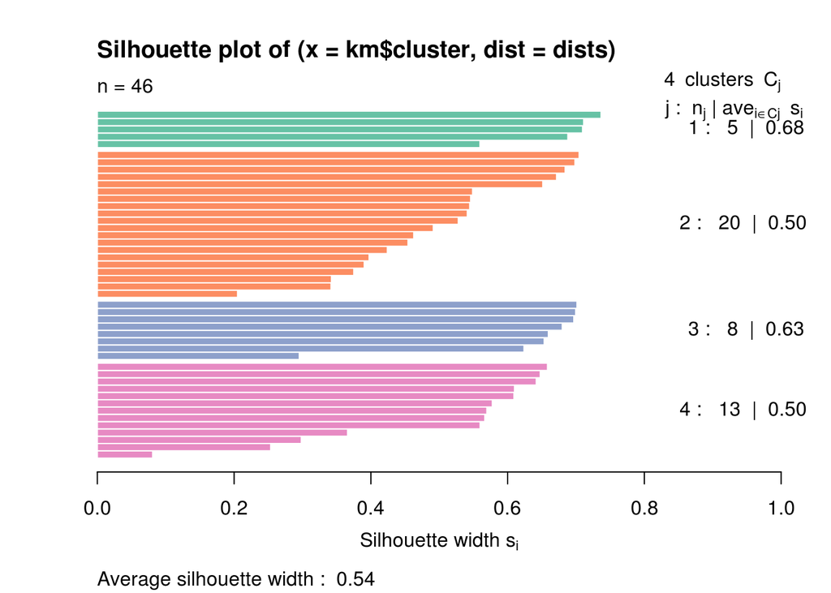

```r
# A silhoueta
dists = select(summario_t, idade_mediana, Professor.40h.ou.DE) %>% dist()
km = kmeans(select(summario_t, idade_mediana, Professor.40h.ou.DE),
            centers = 4,
            nstart = 10)

silhouette(km$cluster, dists) %>%
    plot(col = RColorBrewer::brewer.pal(4, "Set2"))
```

### calculando melhor k

Mesmo com um bom entendimento dos grupos podemos melhorar a escolha do valor de **k** utilizando um metodo **betweenss/totss** no k-means.

**betweenss** é o somatório para cada grupo da distância do centro de cada cluster para o centro dos dados e multiplicado pelo número de pontos nesse mesmo cluster. Já o **totss** é somatório total das distâncias dos pontos para o centro dos dados.

Podemos ver esse comportamento com a junção do scatterplot com uma linha de conexão entre os pontos.

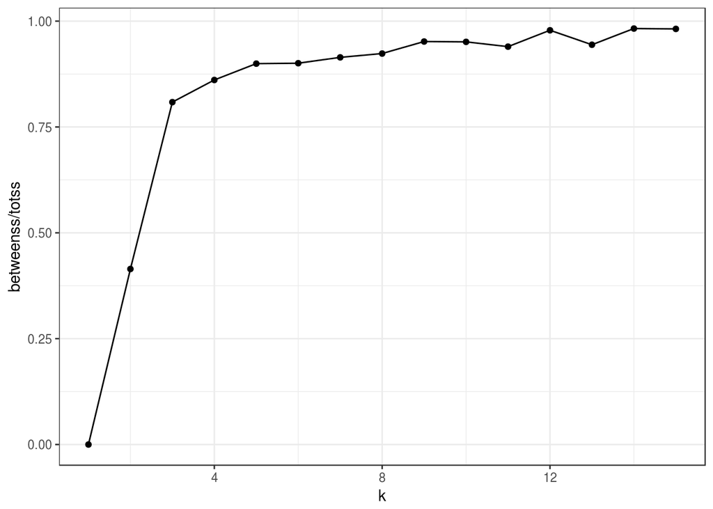

```r
set.seed(123)
explorando_k = tibble(k = 1:15) %>%
    group_by(k) %>%
    do(
        kmeans(select(summario_t, -UORG_LOTACAO),
               centers = .$k,
               nstart = 20) %>% glance()
    )

explorando_k %>%
    ggplot(aes(x = k, y = betweenss / totss)) +
    geom_line() +
    geom_point()
```

### simulação com ultimo k crescente

Basicamente a conclusão deste valor para **k** é que os 4 grupos que foram usados na sessão anterior foram divididos em mais 3 cada um formando esses grupos atuais. Mas a lógica continua a mesma, só ficam mais separados e com mais detalhes.

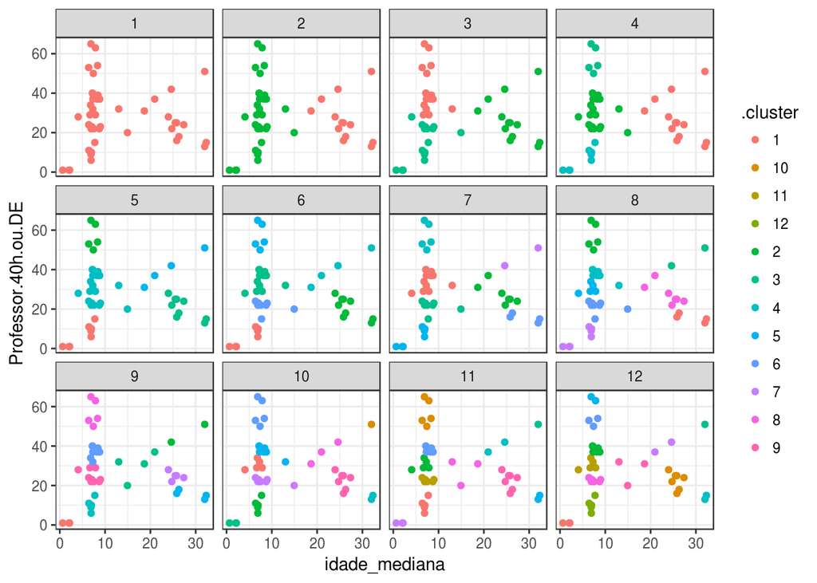

```r
atribuicoes = tibble(k = 1:12) %>%
    group_by(k) %>%
    do(kmeans(select(summario_t, idade_mediana, Professor.40h.ou.DE),
              centers = .$k,
              nstart = 10) %>% augment(summ.ua))

atribuicoes_long = atribuicoes %>%
    gather(key = "variavel", value = "valor", -UORG_LOTACAO, -k, -.cluster, -Outro)

atribuicoes %>%
    ggplot(aes(x = idade_mediana, y = Professor.40h.ou.DE, label = UORG_LOTACAO, colour = .cluster)) +
    geom_point() +
    facet_wrap(~ k)
```

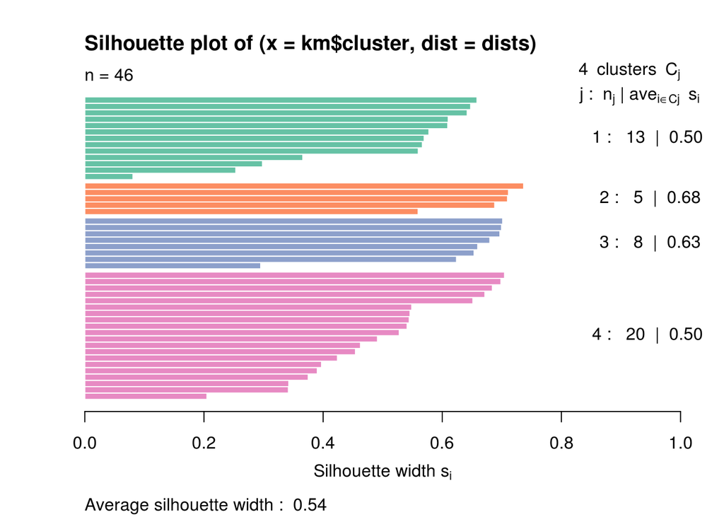

```r
dists = select(summario_t, idade_mediana, Professor.40h.ou.DE) %>% dist()
km = kmeans(select(summario_t, idade_mediana, Professor.40h.ou.DE),
            centers = 4,
            nstart = 10)

silhouette(km$cluster, dists) %>%
    plot(col = RColorBrewer::brewer.pal(4, "Set2"))
```